# Analisis de la Mortalidad por causas 8

Federico Tricarico

2025-08-08

## 1 Intro

Se presenta un analisis de la mortalidad por causas a nivel de departamentos que corresponden al nivel 3, o de Division Administrativa Menor (DAME).

### 1.1 Datos

```r
data_mort <- readRDS("data_salidas/data_mort_01_22.rds")
data_mort_gral <- readRDS("data_salidas/data_mort_depto_01_22.rds")
```

### 1.2 Geodata

Se importan los datos geograficos.

```r
geo_depto <- read_sf("data_geo/departamentos.gpkg")
geo_prov <- read_sf("data_geo/provincias.gpkg")
```

Geodata de Provincias

```r
str(geo_prov)
```

```
## sf [24 × 7] (S3: sf/tbl_df/tbl/data.frame)
##  $ DEPTO_LINK: int [1:24] 34042 90042 26028 10105 46014 74042 22014 86140 70014 82105 ...
##  $ NOMDEPTO  : chr [1:24] "Pilagás" "Juan B. Alberdi" "Florentino Ameghino" "Tinogasta" ...
##  $ prov      : chr [1:24] "34" "90" "26" "10" ...
##  $ fna       : chr [1:24] "Provincia de Formosa" "Provincia de Tucumán" "Provincia del Chubut" "Provincia de Catamarca" ...
##  $ gna       : chr [1:24] "Provincia" "Provincia" "Provincia" "Provincia" ...
##  $ nam       : chr [1:24] "Formosa" "Tucumán" "Chubut" "Catamarca" ...
##  $ geom      :sfc_MULTIPOLYGON of length 24; first list element: List of 1
##   ..$ :List of 1
##   .. ..$ : num [1:13549, 1:2] -58.6 -58.6 -58.6 -58.6 -58.6 ...
##   ..- attr(*, "class")= chr [1:3] "XY" "MULTIPOLYGON" "sfg"
##  - attr(*, "sf_column")= chr "geom"
##  - attr(*, "agr")= Factor w/ 3 levels "constant","aggregate",..: NA NA NA NA NA NA
##   ..- attr(*, "names")= chr [1:6] "DEPTO_LINK" "NOMDEPTO" "prov" "fna" ...
```

Geodata de Departamentos

```r
str(geo_depto)
```

```
## sf [511 × 4] (S3: sf/tbl_df/tbl/data.frame)
##  $ DEPTO_LINK: int [1:511] 26028 82105 30077 6707 6686 26035 82112 30084 26014 6679 ...
##  $ NOMDEPTO  : chr [1:511] "Florentino Ameghino" "San Jerónimo" "Nogoya" "Saladillo" ...
##  $ prov      : chr [1:511] "26" "82" "30" "6" ...
##  $ geom      :sfc_MULTIPOLYGON of length 511; first list element: List of 1
##   ..$ :List of 1
##   .. ..$ : num [1:5047, 1:2] -65.7 -65.7 -65.7 -65.7 -65.7 ...
##   ..- attr(*, "class")= chr [1:3] "XY" "MULTIPOLYGON" "sfg"
##  - attr(*, "sf_column")= chr "geom"
##  - attr(*, "agr")= Factor w/ 3 levels "constant","aggregate",..: NA NA NA
##   ..- attr(*, "names")= chr [1:3] "DEPTO_LINK" "NOMDEPTO" "prov"
```

### 1.3 Mortalidad por causas

```r
names(data_mort)
```

```
## [1] "gedad"     "sexo"      "geocodigo" "anio"      "grupo_oms" "casos"
## [7] "pob"       "label"
```

```r
vars_agg <- c("gedad",     "sexo",      "geocodigo", "label", "anio",      "grupo_oms")

data_mort |>
  group_by_at(vars_agg) |>
  summarise(
    casos = sum(casos, na.rm = TRUE),
    pob = sum(pob, na.rm = TRUE),
    rm = round(casos / pob, 6),
    rmxm = rm * 100000
  ) |>
  arrange(desc(rmxm)) |>
  ungroup() -> data_mort
```

```r
head(data_mort, n=30)
```

```
## # A tibble: 30 × 10
##    gedad    sexo  geocodigo label      anio grupo_oms casos   pob      rm   rmxm
##    <chr>    <chr> <chr>     <chr>     <dbl> <chr>     <int> <dbl>   <dbl>  <dbl>
##  1 70 y mas Varón 94028     Antártid…  2015 Enfermed…     1     0 Inf       Inf
##  2 70 y mas Varón 14154     Sobremon…  2003 Enfermed…    75   140   0.536 53571.
##  3 70 y mas Mujer 42091     Limay Ma…  2003 Enfermed…     2     4   0.5   50000
##  4 70 y mas Varón 78042     Magallan…  2003 Enfermed…    71   153   0.464 46405.
##  5 70 y mas Varón 42063     Chical Co  2003 Enfermed…    11    27   0.407 40741.
##  6 70 y mas Varón 14154     Sobremon…  2009 Enfermed…    63   157   0.401 40127.
##  7 70 y mas Varón 6770      San Pedro  2003 Enfermed…   593  1508   0.393 39324.
##  8 70 y mas Varón 10014     Ancasti    2003 Enfermed…    28    73   0.384 38356.
##  9 70 y mas Varón 6070      Baradero   2003 Enfermed…   364   960   0.379 37917.
## 10 70 y mas Varón 30042     Feliciano  2003 Enfermed…    92   245   0.376 37551
## # ℹ 20 more rows
```

Existe un solo registro donde existe un caso, donde el segmento por edad y sexo de poblacion no existe. O deberia decirse que no fue estimado correctamente, si se considera una poblacion extremo pequeña y altamente variable, que solo fue censada en 2010. (revisar)

```r
data_mort |>
  filter(casos >= 1 & pob == 0)
```

```
## # A tibble: 1 × 10
##   gedad    sexo  geocodigo label          anio grupo_oms casos   pob    rm  rmxm
##   <chr>    <chr> <chr>     <chr>         <dbl> <chr>     <int> <dbl> <dbl> <dbl>
## 1 70 y mas Varón 94028     Antártida Ar…  2015 Enfermed…     1     0   Inf   Inf
```

Se elimina este registro:

```r
data_mort |>
  arrange(desc(rmxm)) |>
  slice(-1)-> data_mort
```

Poblacion extremo baja

```r
data_mort |>
  arrange(pob)
```

```
## # A tibble: 86,015 × 10
##    gedad    sexo  geocodigo label         anio grupo_oms casos   pob    rm  rmxm
##    <chr>    <chr> <chr>     <chr>        <dbl> <chr>     <int> <dbl> <dbl> <dbl>
##  1 70 y mas Mujer 94028     Antártida A…  2003 Condicio…     0     0   NaN   NaN
##  2 70 y mas Mujer 94028     Antártida A…  2003 Enfermed…     0     0   NaN   NaN
##  3 70 y mas Mujer 94028     Antártida A…  2003 Enfermed…     0     0   NaN   NaN
##  4 70 y mas Mujer 94028     Antártida A…  2003 Lesiones      0     0   NaN   NaN
##  5 70 y mas Mujer 94028     Antártida A…  2006 Condicio…     0     0   NaN   NaN
##  6 70 y mas Mujer 94028     Antártida A…  2006 Enfermed…     0     0   NaN   NaN
##  7 70 y mas Mujer 94028     Antártida A…  2006 Enfermed…     0     0   NaN   NaN
##  8 70 y mas Mujer 94028     Antártida A…  2006 Lesiones      0     0   NaN   NaN
##  9 70 y mas Mujer 94028     Antártida A…  2009 Condicio…     0     0   NaN   NaN
## 10 70 y mas Mujer 94028     Antártida A…  2009 Enfermed…     0     0   NaN   NaN
## # ℹ 86,005 more rows
```

Ausencia de eventos

```r
dim(

data_mort |>
  filter(casos==0)
)
```

```
## [1] 10759    10
```

#### 1.3.1 Reflexiones anteriores

El análisis de la mortalidad por causas según edad y sexo a nivel DAME, enfrenta ciertas limitaciones. En primer lugar Los valores extremos se hallan derivados de:

Por un lado, la **baja frecuencia de población** favorece razones (casos / poblacion) muy elevadas, sobre todo cuando existen causas y grupos de edad con alta mortalidad, como las edades avanzadas y enfermedades crónicas no transmisibles ( ~ 30.000 a 50.000 por c/100.000). Por otro lado, **la baja frecuencia en eventos**, por causas poco comunes en segmentos de edad grandes, como por ejemplo las defunciones debidas a Enfermedades Mal definidas en edades jóvenes o menores de 24 años, conducen a razones en extremo bajas ( ~ 1 a 3 por c/100.000) Por último, también sucede que pueden darse casos de defunciones en ciertos segmentos de edad y sexo, para el cual no existe un denominador (en este ejercicio solo un caso) o **no hay poblacion**. Mientras que alternativamente, sucede más frecuente, que **no ocurran eventos** por ciertas causas, en segmentos por edad y sexo, que conducen a razones o tasas Nulas. Esto no indicaría el riesgo cero de fallecer por determinada causa en un grupo de edad y sexo en un área determinada, ya que se debe antes, a la aleatoriedad debida al tamaño de la población, el área, y las características del sistema de clasificación de causas de defunción. El caso se da por ejemplo en las defunciones por Enfermedades mal definidas en mujeres jóvenes donde para casi toda la serie está ausente en al rededor del 50 al 60% de las unidades de área.

Tambien se ha observado anteriormente que la distirbucion de la frecuencia de casos, y de las razones casos / poblacion, es fuertemente asimetrica positiva, con pocos casos con valores altos, y muchos casos con valores muy bajos.

Al observar la mortalidad general por causas, y por grupos de edad y sexo, se usaran metodos de cortes (breaks) o segmentacion de la distirbucion, head-tail, y natural jenks propuesta por fisher.

### 1.4 Head-Tails

se analizan graficamente la distirbucion segun edad, y grupo de causas

```r
data_mort |>
  mutate(
    gedad = factor(gedad, levels = c("Menor de 24", "25 a 69", "70 y mas"), ordered = TRUE),
  )->data_mort
```

#### 1.4.1 Segun edades

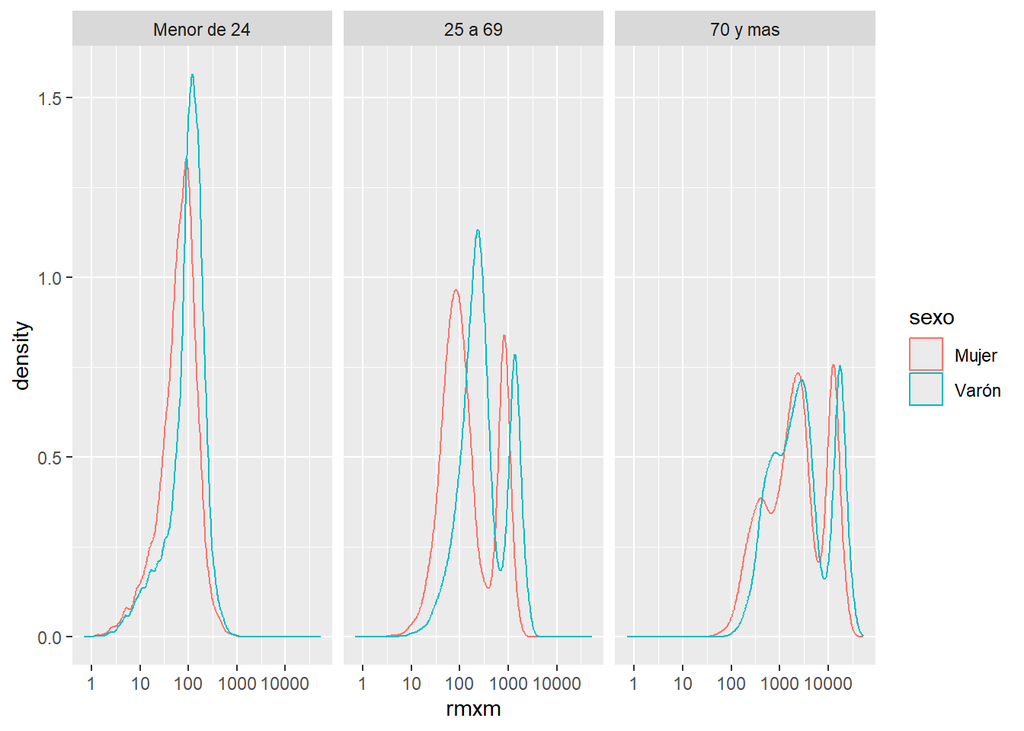

```r
data_mort |>
  filter(anio != 2021) |>
  ggplot(aes(rmxm, colour = sexo))+
  geom_density()+
  scale_x_log10()+
  facet_grid(~gedad)
```

#### 1.4.2 Segun sexo

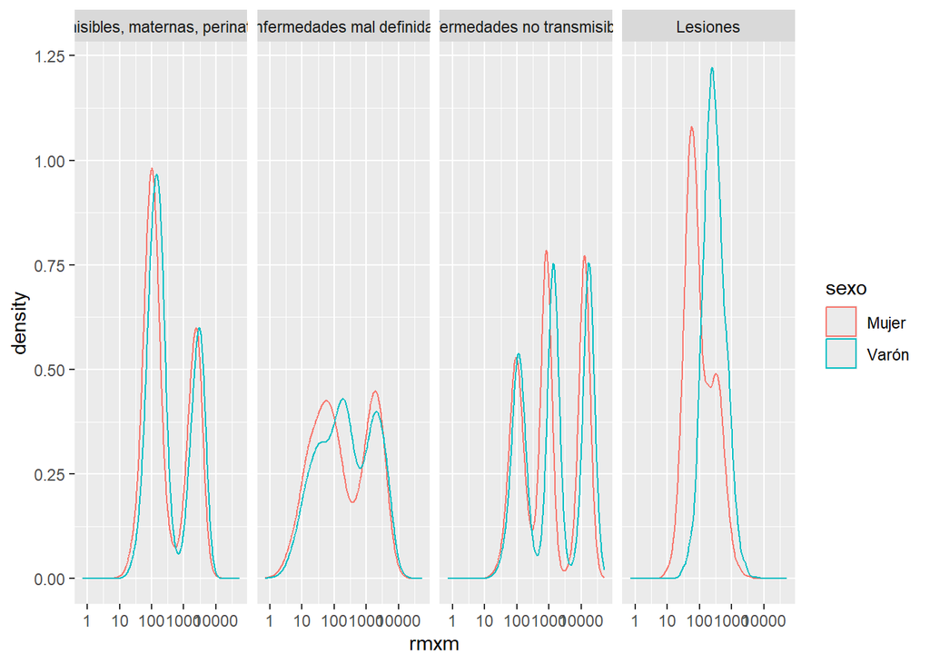

```r
data_mort |>
  filter(anio != 2021) |>
  ggplot(aes(rmxm, colour = sexo))+
  geom_density()+
  scale_x_log10()+
  facet_grid(~grupo_oms)
```

#### 1.4.3 Distribuciones

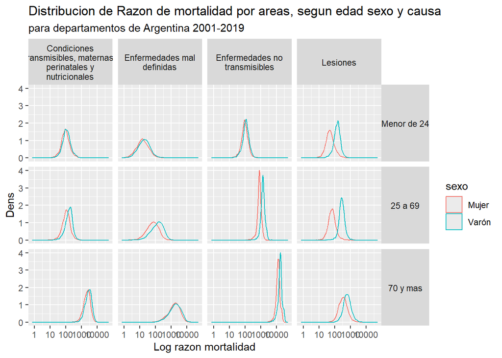

```r
data_mort |>
  filter(anio != 2021) |>
  ggplot(aes(rmxm, colour = sexo))+
  geom_density()+
  scale_x_log10()+
  labs(
    x = "Log razon mortalidad",
    y = "Dens",
    title = "Distribucion de Razon de mortalidad por areas, segun edad sexo y causa",
    subtitle = "para departamentos de Argentina 2001-2019"
  )+
  facet_grid(gedad~grupo_oms, labeller = label_wrap_gen(multi_line = TRUE))+
  theme(
    strip.text.y = element_text(angle = 0, margin = margin())
  )
```

Se observa que:

- Conforme aumenta la edad, la curva se desplaza a la derecha, donde la frecuencia es mas alta.
- Esta variacion es menor en Lesiones donde ademas de la diferencia por sexos, se observa un pico en el centro, mostrando escasa variabilidad, aun con presencia de valores extremos.
- En causada por Enf. no transmisibles se aprecia como el desplazamiento a la derecha, muestra un pico en los valores extremo altos. marcando la pauta de la mortalidad general.
- En cuanto a las Enf. Transmisibles se muestra un pico con valores extremos hacia ambos lados de la distirbucion indicando heterogeneidad de casos, que requiere analisis ulteriores.
- En cuanto a las causadas por Enf mal definidas, se aprecia una distirbucion mas plana, indicando fuerte dispersion en los valores centrales, asi como extremos que se van corriendo a mayor edad. Este grupo al igual que el anterior, justifican un estudio ulterior aparte.

### 1.5 Distribuciones por causa

Se calculan medidas de tendencia central y dispersion.

```r
# Calculo del coeficiente de variacion

vars_agg_cv <- c("gedad", "sexo", "anio", "grupo_oms")

data_mort |>
  group_by_at(vars_agg_cv) |>
  summarise(
    sd = round(sd(rmxm, na.rm = TRUE),2),
    mean = round(abs(mean(rmxm, na.rm = TRUE)),2),
    cv = round(sd / mean * 100, 1)
  )-> data_mort_cv
```

**Ver tabla**

```r
data_mort_cv |>
  kableExtra::kbl() |>
  kableExtra::kable_styling()
```

| gedad | sexo | anio | grupo_oms | sd | mean | cv |
| --- | --- | --- | --- | --- | --- | --- |
| Menor de 24 | Mujer | 2003 | Condiciones transmisibles, maternas, perinatales y nutricionales | 134.57 | 178.82 | 75.3 |
| Menor de 24 | Mujer | 2003 | Enfermedades mal definidas | 45.67 | 16.85 | 271.0 |
| Menor de 24 | Mujer | 2003 | Enfermedades no transmisibles | 91.52 | 135.60 | 67.5 |
| Menor de 24 | Mujer | 2003 | Lesiones | 78.26 | 71.00 | 110.2 |
| Menor de 24 | Mujer | 2006 | Condiciones transmisibles, maternas, perinatales y nutricionales | 80.53 | 98.91 | 81.4 |
| Menor de 24 | Mujer | 2006 | Enfermedades mal definidas | 19.30 | 9.10 | 212.1 |
| Menor de 24 | Mujer | 2006 | Enfermedades no transmisibles | 66.46 | 98.08 | 67.8 |
| Menor de 24 | Mujer | 2006 | Lesiones | 59.11 | 51.97 | 113.7 |
| Menor de 24 | Mujer | 2009 | Condiciones transmisibles, maternas, perinatales y nutricionales | 75.95 | 99.93 | 76.0 |
| Menor de 24 | Mujer | 2009 | Enfermedades mal definidas | 15.20 | 8.95 | 169.8 |
| Menor de 24 | Mujer | 2009 | Enfermedades no transmisibles | 59.24 | 95.52 | 62.0 |
| Menor de 24 | Mujer | 2009 | Lesiones | 56.55 | 52.02 | 108.7 |
| Menor de 24 | Mujer | 2012 | Condiciones transmisibles, maternas, perinatales y nutricionales | 72.76 | 83.83 | 86.8 |
| Menor de 24 | Mujer | 2012 | Enfermedades mal definidas | 14.52 | 7.17 | 202.5 |
| Menor de 24 | Mujer | 2012 | Enfermedades no transmisibles | 59.18 | 89.06 | 66.4 |
| Menor de 24 | Mujer | 2012 | Lesiones | 76.62 | 53.89 | 142.2 |
| Menor de 24 | Mujer | 2015 | Condiciones transmisibles, maternas, perinatales y nutricionales | 60.97 | 76.21 | 80.0 |
| Menor de 24 | Mujer | 2015 | Enfermedades mal definidas | 18.65 | 8.26 | 225.8 |
| Menor de 24 | Mujer | 2015 | Enfermedades no transmisibles | 54.43 | 82.13 | 66.3 |
| Menor de 24 | Mujer | 2015 | Lesiones | 49.07 | 44.14 | 111.2 |
| Menor de 24 | Mujer | 2018 | Condiciones transmisibles, maternas, perinatales y nutricionales | 50.84 | 64.09 | 79.3 |
| Menor de 24 | Mujer | 2018 | Enfermedades mal definidas | 18.95 | 7.81 | 242.6 |
| Menor de 24 | Mujer | 2018 | Enfermedades no transmisibles | 50.43 | 74.54 | 67.7 |
| Menor de 24 | Mujer | 2018 | Lesiones | 39.67 | 40.41 | 98.2 |
| Menor de 24 | Mujer | 2021 | Condiciones transmisibles, maternas, perinatales y nutricionales | 51.16 | 53.30 | 96.0 |
| Menor de 24 | Mujer | 2021 | Enfermedades mal definidas | 16.50 | 6.99 | 236.1 |
| Menor de 24 | Mujer | 2021 | Enfermedades no transmisibles | 42.69 | 61.16 | 69.8 |
| Menor de 24 | Mujer | 2021 | Lesiones | 47.80 | 34.52 | 138.5 |
| Menor de 24 | Varón | 2003 | Condiciones transmisibles, maternas, perinatales y nutricionales | 156.22 | 216.48 | 72.2 |
| Menor de 24 | Varón | 2003 | Enfermedades mal definidas | 36.61 | 21.51 | 170.2 |

[output cut: 138 more lines]

Visualmente para cada grupo de causas, segun edad y sexo, se observa la evolucion de la media de los departamentos, y el desvio estandar.

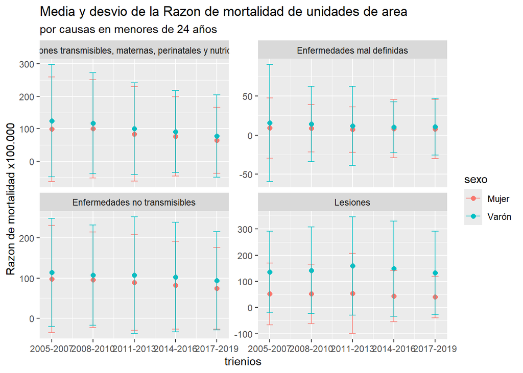

```r
data_mort |>
  filter(gedad == "Menor de 24", !anio %in% c(2003, 2021)) |>
  ggplot(aes(anio, rmxm, colour = sexo)) +
  stat_summary(fun = mean, geom = "point", size = 2) + # Plot mean as points
  stat_summary(fun.data = mean_sdl, geom = "errorbar",width = 0.5, alpha=.8)+
  scale_x_continuous(breaks = anios, labels = label_anios)+
  facet_wrap(~grupo_oms, scales="free_y") +
  labs(
    title = "Media y desvio de la Razon de mortalidad de unidades de area",
    subtitle = "por causas en menores de 24 años",
    x = "trienios",
    y = "Razon de mortalidad x100.000"
  )
```

Se aprecian diferencias por sexo notables en Lesiones como es esperable, con incrementos inicialmente y descenso al final. Se observa una mayor homogeneidad en el descenso de la media por Enfermedades Transimisibles, maternas y perinatales, sobre todo al bajar los niveles extremo altos. Es estable en no transmisibles y Lesiones. Mientras se observa esttable en mal definidas se aprecia un reduccion de los extremos, por tanto mayor homogeneidad.

### 1.6 Tres mapas

#### 1.6.1 No transmisibles

Se crea un subset para 2018, de enfermedades no transmisibles

```r
data_mort |>
  filter(anio == 2018, grupo_oms == "Enfermedades no transmisibles") |>
  arrange(rmxm) |>
  merge(geo_depto, by.x = "geocodigo", by.y = "DEPTO_LINK") -> map_nt_18
# glimpse(map_nt_18)
```

```r
map_nt_18 <- st_as_sf(map_nt_18)
```

```r
# tabla por depto, cols edad

map_nt_18 |>
  select(geocodigo, gedad, sexo, rmxm ) |>
  mutate(
    gedad = recode(
      gedad,
      "Menor de 24" = "jovenes",
      "25 a 69" = "adultos",
      "70 y mas" = "mayores",
    )
  ) |>
  pivot_wider(
    names_from = gedad,
    names_prefix = "e_",
    values_from = rmxm
  )-> map1
# glimpse(map1)
```

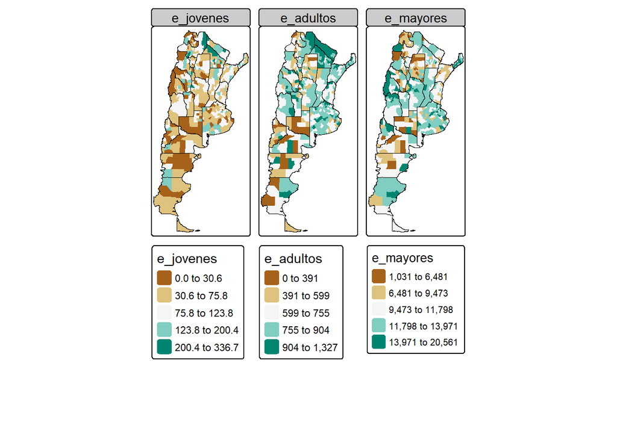

```r
map1 |>
  filter(sexo != "Varón") |>
  tm_shape()+
  tm_polygons(
    fill = c("e_jovenes", "e_adultos", "e_mayores"),
    fill.scale =
      list(tm_scale_intervals(style = "fisher", values = "BrBG"),
         tm_scale_intervals(style = "fisher", values = "BrBG"),
         tm_scale_intervals(style = "fisher", values = "BrBG")),
    col = NULL
  )+
  # tm_facets_grid(columns = "sexo")+
  tm_shape(geo_prov)+
  tm_borders(col = "black",lwd = 1)
```

#### 1.6.2 Mal definidas

```r
data_mort |>
  filter(anio == 2018, grupo_oms == "Enfermedades mal definidas") |>
  arrange(rmxm) |>
  merge(geo_depto, by.x = "geocodigo", by.y = "DEPTO_LINK") -> map_md_18
# glimpse(map_md_18)
```

```r
map_md_18 <- st_as_sf(map_md_18)
```

```r
# tabla por depto, cols edad

map_md_18 |>
  select(geocodigo, gedad, sexo, rmxm ) |>
  mutate(
    gedad = recode(
      gedad,
      "Menor de 24" = "jovenes",
      "25 a 69" = "adultos",
      "70 y mas" = "mayores",
    )
  ) |>
  pivot_wider(
    names_from = gedad,
    names_prefix = "e_",
    values_from = rmxm
  )-> map2
# glimpse(map2)
```

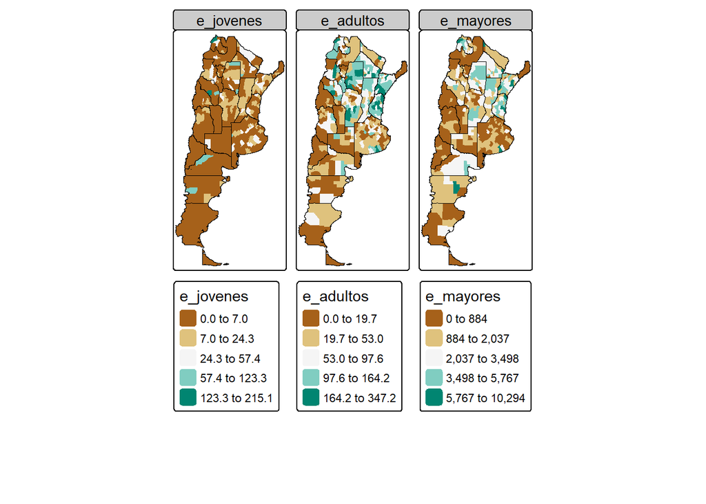

```r
map2 |>
  filter(sexo != "Varón") |>
  tm_shape()+
  tm_polygons(
    fill = c("e_jovenes", "e_adultos", "e_mayores"),
    fill.scale =
      list(tm_scale_intervals(style = "fisher", values = "BrBG"),
         tm_scale_intervals(style = "fisher", values = "BrBG"),
         tm_scale_intervals(style = "fisher", values = "BrBG")),
    col = NULL
  )+
  # tm_facets_grid(columns = "sexo")+
  tm_shape(geo_prov)+
  tm_borders(col = "black",lwd = 1)
```

#### 1.6.3 La poblacion

```r
### distribucion de la poblacion
vars_agg_pob <- c("gedad","sexo","geocodigo")
data_mort |>
  filter(anio == 2018) |>
  group_by_at(vars_agg_pob) |>
  distinct(geocodigo, sexo, gedad, pob) |>
  merge(geo_depto, by.x = "geocodigo", by.y = "DEPTO_LINK") -> map_pob

map_pob <- st_as_sf(map_pob)
map_pob |>
  mutate(
    gedad = recode(
      gedad,
      "Menor de 24" = "jovenes",
      "25 a 69" = "adultos",
      "70 y mas" = "mayores",
    )
  ) |>
  pivot_wider(
    names_from = gedad,
    names_prefix = "e_",
    values_from = pob
  )-> map3
```

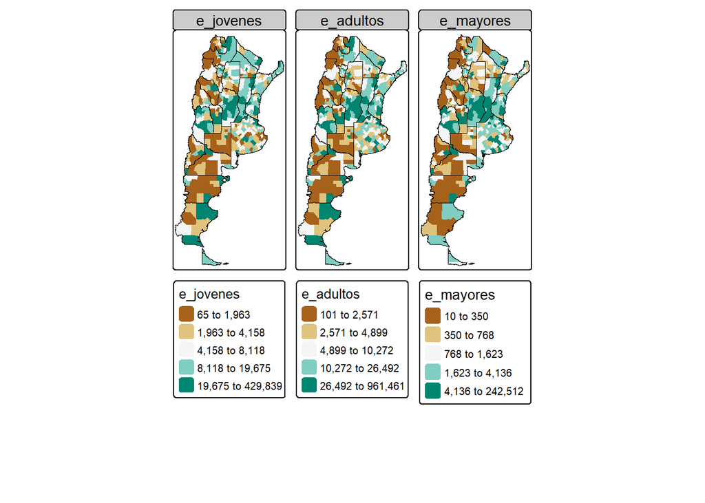

```r
map3 |>
  filter(sexo != "Varón") |>
  tm_shape()+
  tm_polygons(
    fill = c("e_jovenes", "e_adultos", "e_mayores"),
    fill.scale =
      list(tm_scale_intervals(style = "quantile",n = 5, values = "BrBG"),
         tm_scale_intervals(style = "quantile",n = 5, values = "BrBG"),
         tm_scale_intervals(style = "quantile",n = 5, values = "BrBG")),
    col = NULL
  )+
  # tm_facets_grid(columns = "sexo")+
  tm_shape(geo_prov)+
  tm_borders(col = "black",lwd = 1)
```

### 1.7 Conclusiones parciales

Al ver los tres mapas, en zonas podemos sacara algunas conclusiones.

Surge una idea de hacer un mapa tri o bivariado donde se mezclen.  
- Numero de habitantes. offset de poblacion. - Tasa o razon de mortalidad. por determinas causas - Porcentaje de defunciones o Tasa/razon por **Enf. mal definidas**

### 1.8 Export data

```r
unique(data_mort$grupo_oms)
```

```
## [1] "Enfermedades no transmisibles"
## [2] "Condiciones transmisibles, maternas, perinatales y nutricionales"
## [3] "Enfermedades mal definidas"
## [4] "Lesiones"
```

```r
data_mort |>
  mutate(
    gedad = recode(
      gedad,
      "Menor de 24" = "e24_",
      "25 a 69" = "e25_",
      "70 y mas" = "e70_"
    ),
    sexo = recode(
      sexo,
      "Varón" = 1,
      "Mujer" = 2
    ),
    grupo_oms = recode(
      grupo_oms,
      "Condiciones transmisibles, maternas, perinatales y nutricionales" = "trans",
      "Enfermedades no transmisibles" = "notrans",
      "Enfermedades mal definidas" = "maldef",
      "Lesiones" = "lesi"
    )
  ) |>
  select(1:8)-> data_mortalidad_deptos
```

```r
glimpse(data_mortalidad_deptos)
```

```
## Rows: 86,015
## Columns: 8
## $ gedad     <ord> e70_, e70_, e70_, e70_, e70_, e70_, e70_, e70_, e70_, e70_, …
## $ sexo      <dbl> 1, 2, 1, 1, 1, 1, 1, 1, 1, 1, 1, 1, 1, 1, 2, 1, 1, 1, 1, 1, …
## $ geocodigo <chr> "14154", "42091", "78042", "42063", "14154", "6770", "10014"…
## $ label     <chr> "Sobremonte", "Limay Mahuida", "Magallanes", "Chical Co", "S…
## $ anio      <dbl> 2003, 2003, 2003, 2003, 2009, 2003, 2003, 2003, 2003, 2003, …
## $ grupo_oms <chr> "notrans", "notrans", "notrans", "notrans", "notrans", "notr…
## $ casos     <int> 75, 2, 71, 11, 63, 593, 28, 364, 92, 43, 60, 179, 177, 128, …
## $ pob       <dbl> 140, 4, 153, 27, 157, 1508, 73, 960, 245, 116, 165, 494, 490…
```

```r
# saveRDS(data_mortalidad_deptos, "data_salidas/data_mortalidad_deptos.rds")
# write.csv2(data_mortalidad_deptos, "data_salidas/data_mortalidad_deptos.csv", fileEncoding = "latin1")
```

```r
# data_mortalidad_deptos |>
#   pivot_wider(
#     names_from = c(gedad, sexo, grupo_oms),
#     values_from = c(casos, pob)
#   ) -> data_mortalidad_deptos_wide
# head(data_mortalidad_deptos_wide)
```

```r
# list_anual_data_mort <- split(data_mortalidad_deptos_wide, data_mortalidad_deptos_wide$anio)
```

```r
# for (anio in names(list_anual_data_mort)) {
#   file_name <- paste0("salida_csv/mort_", anio, ".csv")
#   write.csv(list_anual_data_mort[[anio]], file = file_name, row.names = FALSE, fileEncoding = "latin1" )
# }
```

```r
# data_mortalidad_deptos |>
#   pivot_wider(
#     names_from = c(gedad, sexo, grupo_oms),
#     values_from = c(casos, pob)
#   ) |>
#   merge(geo_depto, by.x = "geocodigo", by.y = "DEPTO_LINK") |>
#   select(-NOMDEPTO)-> geodata_mortalidad_deptos_wide
#
# geodata_mortalidad_deptos_wide <- st_as_sf(geodata_mortalidad_deptos_wide)
# str(geodata_mortalidad_deptos_wide)
```

```r
# list_geodata_mortalidad_deptos_wide <- split(geodata_mortalidad_deptos_wide, geodata_mortalidad_deptos_wide$anio)
```

```r
# for (anio in names(list_geodata_mortalidad_deptos_wide)) {
#   file_name <- paste0("salida_geo/mort_", anio, ".gpkg")
#   st_write(list_geodata_mortalidad_deptos_wide[[anio]], dsn = file_name, options = c("ENCODING=LATIN1"))
# }
```

```r
# write_sf(geo_data_mort_depto, "data_salidas_geo/geo_data_mort_depto.gpkg")
```

```r
# st_write(obj = geo_data_mort_depto, dsn = "data_salidas_geo/geodata_mort_depto.gpkg", layer = "mortalidad_deptos")
```